# Analysis of variance: ANOVA

### Interpretation of result result

The impact of sleep and medicine will be called `main effects` and the interaction between these two will be called `interaction effect`. To make things easier, we just apply one way ANOVA on the first table we have. In real world, when our data is too big for us to grapes the characteristics, we can apply some exploratory analysis on the data set just to get a feeling. The purpose of ANOVA here is to understand if the amount of sleep that one gets has an impact on his/her wellness.

```r
aggregate(sleep$Wellness, by=list(sleep$Sleep.amount), FUN=mean)
```

```
##          Group.1    x
## 1 Greater than 8 3.04
## 2 Smaller than 8 1.32
```

Easily we can tell that the wellness of the group that have more sleep feel better than the group that doesn’t as much sleep.

```r
table(sleep)
```

```
##         Sleep.amount
## Wellness Greater than 8 Smaller than 8
##      0.3              0              1
##      0.4              0              1
##      1.8              0              1
##      2                0              1
##      2.1              0              1
##      2.3              1              0
##      3.2              3              0
##      3.3              1              0
```

Shows us the group sample sizes.

```r
fit <- aov(sleep$Wellness ~ sleep$Sleep.amount)
summary(fit)
```

```
##                    Df Sum Sq Mean Sq F value  Pr(>F)
## sleep$Sleep.amount  1  7.396   7.396   15.25 0.00451 **
## Residuals           8  3.880   0.485
## ---
## Signif. codes:  0 '***' 0.001 '**' 0.01 '*' 0.05 '.' 0.1 ' ' 1
```

We can tell that the probability of getting F value 15.25 is smaller than 0.01 so that we can conclude having different amounts of sleep yields different wellness levels.

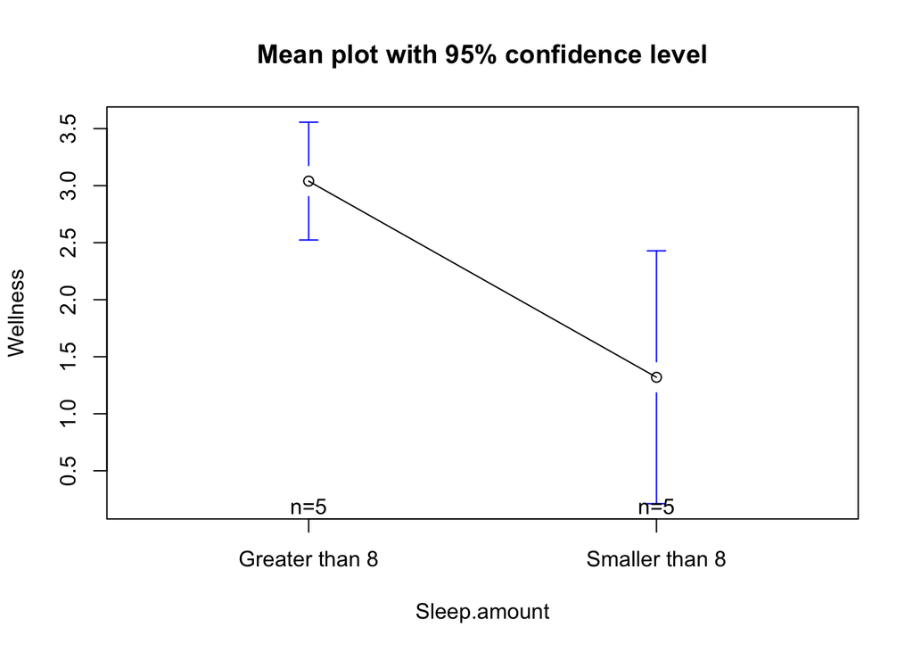

```r
library(gplots)
plotmeans(Wellness ~ Sleep.amount, data=sleep, main = "Mean plot with 95% confidence level", p = 0.95)
```

It is easier to see from the graph the differece between the group means at 95% confidence level.